# Визуализация данных с помощью ggplot2, часть 1

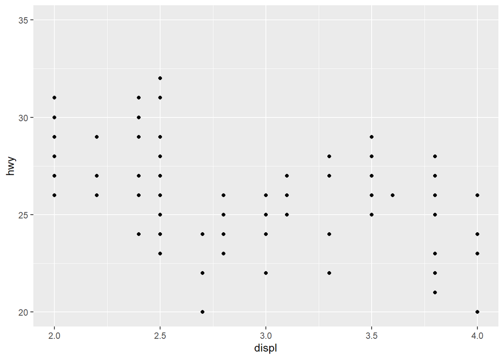

```r
# или + scale_x_continuous(limits = c(2, 4))

# Ограничение области визуализации с помощью координатной системы
p + coord_cartesian(xlim = c(2, 4), ylim = c(20, 35))
```

Хотя визуально графики не отличаются, на них отражен разный объем данных. Поэтому, если мы будем добавлять на визуализацию еще какие-нибудь слои, то результат может отличаться.

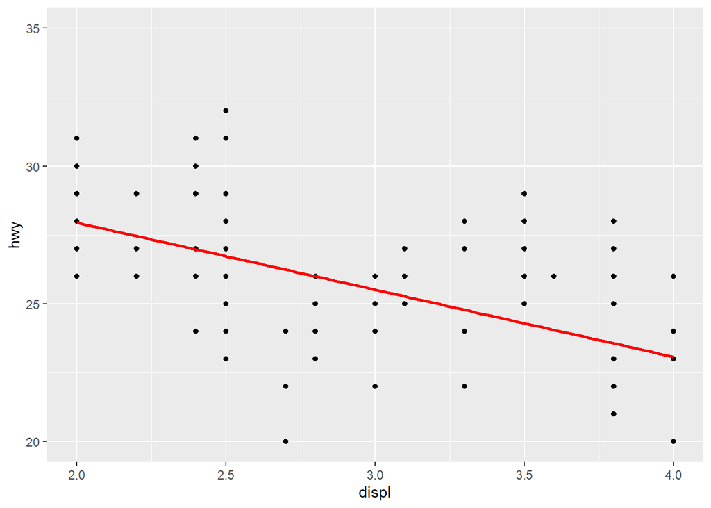

```r
# Ограничение области визуализации с помощью шкалы
p + xlim(2, 4) + ylim(20, 35) +
  geom_smooth(method = 'lm', se = FALSE, color = 'red')
```

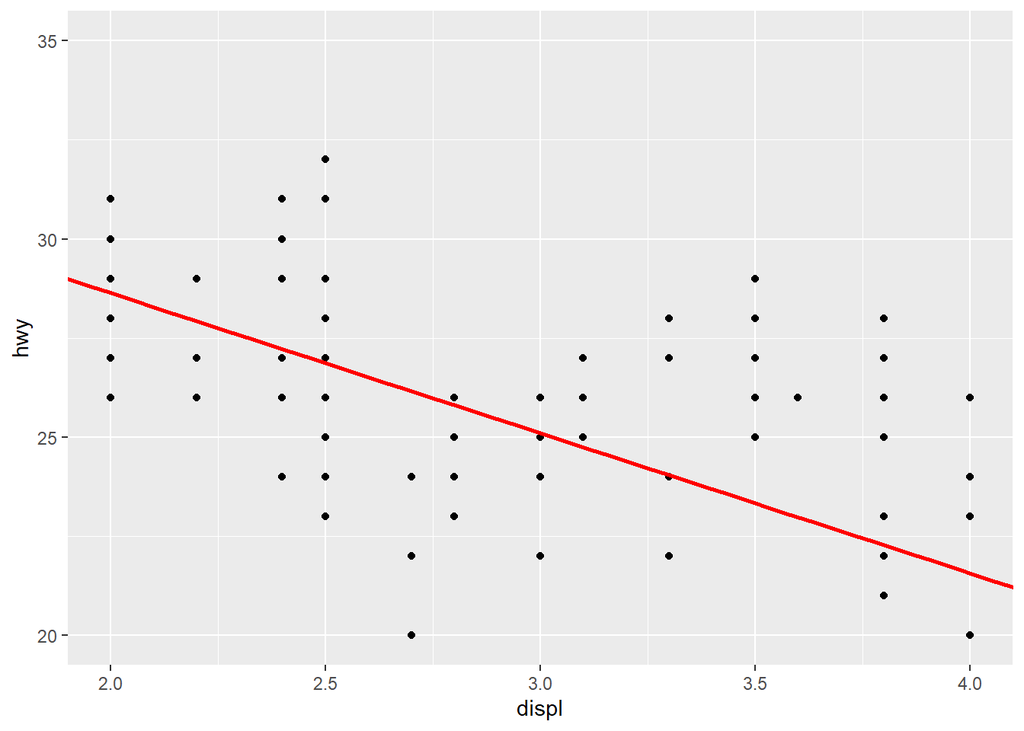

```r
# Ограничение области визуализации с помощью координатной системы
p + coord_cartesian(xlim = c(2, 4), ylim = c(20, 35)) +
  geom_smooth(method = 'lm', se = FALSE, color = 'red')
```

Положение линий тренда на графиках отличается. На первом графике тренд построен только по тем данным, которые попали в окно диаграммы (остальные данные отфильтрованы). На втором - по всем данным, даже тем, которые на графике не видны.

Что же выбрать? Оба метода полезны в определенной ситуации. Например, если в ваших данных есть выбросы и вы не хотите, чтобы линии тренда или опорные линии (среднее, медиана) для этих данных смещались из-за них, то можно отфильтровать эти выбросы, задав пределы при помощи шкалы.

Если вы хотите получше рассмотреть какую-нибудь область графика, но при этом не хотите искажать статистики из-за фильтрации, то лучше использовать ограничение области просмотра с помощью координатной системы.

# Приложение 3. Как сделать понятные подписи для графиков

В `ggplot2` оформление графиков можно гибко настраивать. Рекомендуем изучить раздел про оформление графиков в книге [R for Data Science](http://r4ds.had.co.nz/graphics-for-communication.html).

Здесь же мы покажем, как задать понятные подписи для графика. Это необходимо делать во всех графиках, которые вы намереваетесь кому-то показывать.

Для определения подписей на графике можно использовать функции, изменяющие отдельные элементы - например, `xlab()` - для изменения подписи для оси `x`. Но удобнее использовать функцию `labs()`, которая позволяет задать все подписи сразу.

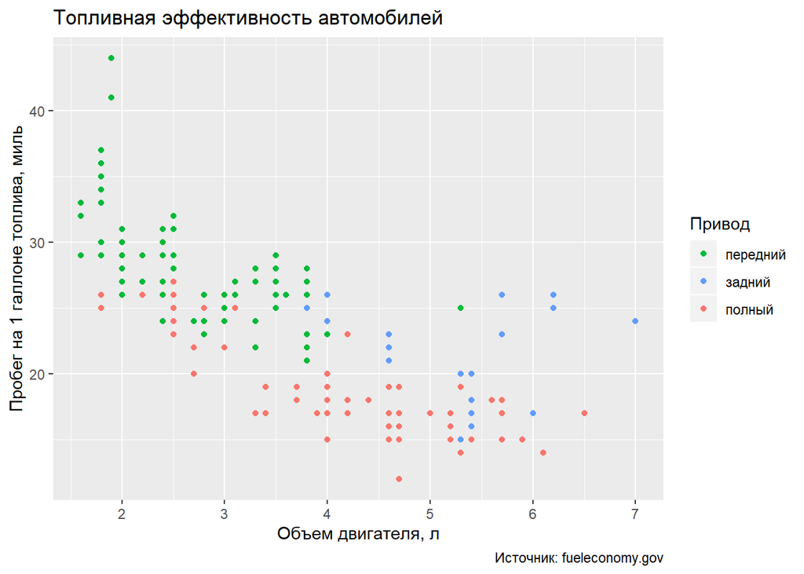

```r
ggplot(data = mpg) +
  geom_point(mapping = aes(x = displ, y = hwy,
                           colour = drv)) +
  scale_color_discrete(breaks = c('f', 'r', '4'),
                       labels = c('передний',
                                  'задний',
                                  'полный')) +
  labs(title = 'Топливная эффективность автомобилей',
       x = 'Объем двигателя, л',
       y = 'Пробег на 1 галлоне топлива, миль',
       color = 'Привод',
       caption = 'Источник: fueleconomy.gov')
```